# STAT 184 Final Project

Guneet Kaur Baweja

December 14, 2020

### Load Required Packages

##### Start by loading the packages and data sets necessary for the project.

```r
#load R packages and data sets required for the project

library(rvest)
library(tidyverse)
library(genius)
library(tidytext)
library(gridExtra)
library(tidytext)
library(ggplot2)
data("stop_words")
data("sentiments")
```

### Part 1 : DATA ACCESS

##### The very first step to begin with the project is to first scrap the data from an external website (wikipedia), read it in R and work with its tables. Here I create 4 tables to get the data from 4 decades of Grammy nominations. I convert them into list of length 1 so that it’s reasy to reduce them into one table.

```r
#read webpage for Grammy Awards
webpage <- read_html("https://en.wikipedia.org/wiki/Grammy_Award_for_Record_of_the_Year")

#copy XPATH for table of 1980s
XPATH80 <- '/html/body/div[3]/div[3]/div[5]/div[1]/table[5]'

# run the following to create table of songs from 1980s
table_1980 <-
  webpage %>%
  html_nodes(xpath = XPATH80) %>%
  html_table(fill = TRUE)

#creating a list for the songs from 1980s
d1980 <- table_1980[[1]]


# copy xpath for table of 1990s
XPATH90 <- '/html/body/div[3]/div[3]/div[5]/div[1]/table[6]'

# run the following to create table of songs from 1990s
table_1990 <-
  webpage %>%
  html_nodes(xpath = XPATH90) %>%
  html_table(fill = TRUE)

#creating a list for the songs from 1990s
d1990 <- table_1990[[1]]


# copy xpath for table of 2000s
XPATH00 <- '/html/body/div[3]/div[3]/div[5]/div[1]/table[7]'

# run the following to create table of songs from 2000s
table_2000 <-
  webpage %>%
  html_nodes(xpath = XPATH00) %>%
  html_table(fill = TRUE)

#creating a list for the songs from 2000s
d2000 <- table_2000[[1]]


# copy xpath for table of 2010s
XPATH10 <- '/html/body/div[3]/div[3]/div[5]/div[1]/table[8]'

# run the following to create table of songs from 2010s
table_2010 <-
  webpage %>%
  html_nodes(xpath = XPATH10) %>%
  html_table(fill = TRUE)

#creating a list for the songs from 2010s
d2010 <- table_2010[[1]]
```

### Part 2: DATA WRANGLING (CONTD.)

##### Create data set that combines all the records into one data frame called combined_table. Now, I clean the table to rename columns such as Year[I] to year, Record to track and Artist(s) to artist. I also extract year variable without the subscript and to remove footnotes using the extract function and regular expression (regex=“([[:digit:]]{4})”), which keeps just the first 4 digits of the year variable and not [44],[46],etc. Finally lyrics are added from the genius package to the table with the tidy data.

```r
# create a combined table containing songs from all decades (1980s to 2010s)
combined_table <-
  Reduce(function(x, y) merge(x, y, all=TRUE), list(table_1980, table_1990,table_2000, table_2010)) %>%
  na.omit(combined_table)%>%
  rename(year = Year.I., track= Record, artist= Artist.s.)

# clean the table to get tidy data
clean_table<-
  extract(combined_table,col = "year" , into= "year", regex = "([[:digit:]]{4})" )

final_clean_table<-
  subset(clean_table, select = -c(Production.team) )


# using the genius package to add lyrics to the tidy data table called lyrics_final, containing songs from all decades (1980s to 2000s)
lyrics_final<-
  final_clean_table %>%
  add_genius(artist, track, type = "lyrics")
```

### Part 3: DATA VISUALIZATION

##### GRAPH 1: Here I start by creating a new variable called decade by using the mutate function and ifelse conditions. The decade variable is one of the most important parts of this part of the project since it’s used in almost all the graphs giving to us in some way. Although, while reading the project description, I thought of this part as being the simplier one, it turned out to be tricky. This is where I spent most time, but I’m glad that I could read, research, experiment and come up with a way of creating it. I then unnest the lyrics of the song to count the words per song to prepare Graph 1. (This is before filtering the stop words from the lyrics)

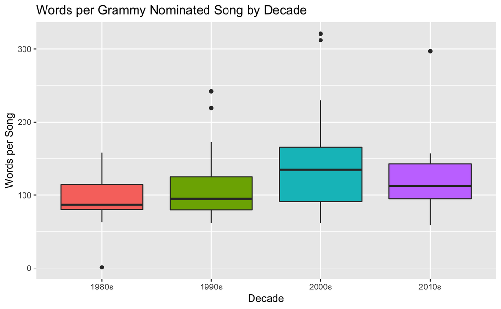

```r
# creating a new variable called decade using mutate function in the table lyrics_final
lyrics_final<-
  lyrics_final%>%
  mutate (lyrics_final, decade= ifelse(year=="1980","1980s",ifelse(year=="1981", "1980s", ifelse(year== "1982", "1980s", ifelse(year=="1983", "1980s",ifelse(year=="1984","1980s", ifelse(year=="1985","1980s",ifelse(year=="1986","1980s",ifelse(year=="1987","1980s",ifelse(year=="1988","1980s",ifelse(year=="1989","1980s",ifelse(year=="1990","1990s",ifelse(year=="1991", "1990s", ifelse(year== "1992", "1990s", ifelse(year=="1993", "1990s",ifelse(year=="1994","1990s", ifelse(year=="1995","1990s",ifelse(year=="1996","1990s",ifelse(year=="1997","1990s",ifelse(year=="1998","1990s",ifelse(year=="1999","1990s",ifelse(year=="2000","2000s",ifelse(year=="2001", "2000s", ifelse(year== "2002", "2000s", ifelse(year=="2003", "2000s",ifelse(year=="2004","2000s", ifelse(year=="2005","2000s",ifelse(year=="2006","2000s",ifelse(year=="2007","2000s",ifelse(year=="2008","2000s",ifelse(year=="2009","2000s","2010s")))))))))))))))))))))))))))))))

# creating a table to unnest the lyrics of the song and count the words per song in order to prepare Graph 1
Combine_decade<-
  lyrics_final%>%
  unnest_tokens(word,lyric)%>%
  group_by(decade,track)%>%
  count(word, sort = TRUE)%>%
  summarise(total=n())
# using the Combine_decade data frame to create a boxplot of words per Grammy nominated song by decade
 ggplot(Combine_decade)+
  aes(x=decade, y=total, fill=decade)+
  geom_boxplot(show.legend = FALSE)+
  labs(title = "Words per Grammy Nominated Song by Decade",x="Decade", y="Words per Song")
```

```r
NA
NA
```